# Reference Airline Satisfaction

2025-02-27

# Airline Customer Satisfaction: EFA, Logistic Regression, & Visualizations

## Table of Contents

1. Goals

2. Dataset

3. Cleaning the dataset

4. Correlation Matrix

5. Exploratory Factor Analysis

6. Exploratory Factor Analysis Interpretation

7. Logistic Regression

8. Prediction on Test Data

9. Results of Logistic Regression

10. Visualizations

### Goals

1. Conduct an exploratory factor analysis to find out latent variables and understand which customer satisfaction factors group together
2. Which factors affect satisfaction the most? Conduct logistic regression to find this out
3. Explore the significant variables and visualize them.

### Packages and libraries

```r
# install.packages(c("psych","GPArotation"), dependencies = TRUE)
# install.packages("tidyverse")
library(tidyr)
library(dplyr)
library(tidyverse)
```

```r
library(corrplot)
library(psych)
library(GPArotation)
```

### Dataset

```r
ds <- read.csv("airline_passenger_satisfaction.csv")
head(ds)
```

```
##   ID Gender Age Customer.Type Type.of.Travel    Class Flight.Distance
## 1  1   Male  48    First-time       Business Business             821
## 2  2 Female  35     Returning       Business Business             821
## 3  3   Male  41     Returning       Business Business             853
## 4  4   Male  50     Returning       Business Business            1905
## 5  5 Female  49     Returning       Business Business            3470
## 6  6   Male  43     Returning       Business Business            3788
##   Departure.Delay Arrival.Delay Departure.and.Arrival.Time.Convenience
## 1               2             5                                      3
## 2              26            39                                      2
## 3               0             0                                      4
## 4               0             0                                      2
## 5               0             1                                      3
## 6               0             0                                      4
##   Ease.of.Online.Booking Check.in.Service Online.Boarding Gate.Location
```

[output cut: 27 more lines]

```r
dim(ds)
```

```
## [1] 129880     24
```

```r
str(ds)
```

```
## 'data.frame':    129880 obs. of  24 variables:
##  $ ID                                    : int  1 2 3 4 5 6 7 8 9 10 ...
##  $ Gender                                : chr  "Male" "Female" "Male" "Male" ...
##  $ Age                                   : int  48 35 41 50 49 43 43 60 50 38 ...
##  $ Customer.Type                         : chr  "First-time" "Returning" "Returning" "Returning" ...
##  $ Type.of.Travel                        : chr  "Business" "Business" "Business" "Business" ...
##  $ Class                                 : chr  "Business" "Business" "Business" "Business" ...
##  $ Flight.Distance                       : int  821 821 853 1905 3470 3788 1963 853 2607 2822 ...
##  $ Departure.Delay                       : int  2 26 0 0 0 0 0 0 0 13 ...
##  $ Arrival.Delay                         : int  5 39 0 0 1 0 0 3 0 0 ...
##  $ Departure.and.Arrival.Time.Convenience: int  3 2 4 2 3 4 3 3 1 2 ...
##  $ Ease.of.Online.Booking                : int  3 2 4 2 3 4 3 4 1 5 ...
##  $ Check.in.Service                      : int  4 3 4 3 3 3 4 3 3 3 ...
##  $ Online.Boarding                       : int  3 5 5 4 5 5 4 4 2 5 ...
##  $ Gate.Location                         : int  3 2 4 2 3 4 3 4 1 2 ...
##  $ On.board.Service                      : int  3 5 3 5 3 4 5 3 4 5 ...
##  $ Seat.Comfort                          : int  5 4 5 5 4 4 5 4 3 4 ...
##  $ Leg.Room.Service                      : int  2 5 3 5 4 4 5 4 4 5 ...
##  $ Cleanliness                           : int  5 5 5 4 5 3 4 4 3 4 ...
##  $ Food.and.Drink                        : int  5 3 5 4 4 3 5 4 3 2 ...
##  $ In.flight.Service                     : int  5 5 3 5 3 4 5 3 4 5 ...
##  $ In.flight.Wifi.Service                : int  3 2 4 2 3 4 3 4 4 2 ...
##  $ In.flight.Entertainment               : int  5 5 3 5 3 4 5 3 4 5 ...
##  $ Baggage.Handling                      : int  5 5 3 5 3 4 5 3 4 5 ...
##  $ Satisfaction                          : chr  "Neutral or Dissatisfied" "Satisfied" "Satisfied" "Satisfied" ...
```

**Observations**

### Cleaning the dataset

- Let’s check the presence of NA’s , outliers, and variables that are not useful

```r
any(is.na(ds))
```

```
## [1] TRUE
```

```r
summary(ds)
```

```
##        ID            Gender               Age        Customer.Type
##  Min.   :     1   Length:129880      Min.   : 7.00   Length:129880
##  1st Qu.: 32471   Class :character   1st Qu.:27.00   Class :character
##  Median : 64941   Mode  :character   Median :40.00   Mode  :character
##  Mean   : 64941                      Mean   :39.43
##  3rd Qu.: 97410                      3rd Qu.:51.00
##  Max.   :129880                      Max.   :85.00
##
##  Type.of.Travel        Class           Flight.Distance Departure.Delay
##  Length:129880      Length:129880      Min.   :  31    Min.   :   0.00
##  Class :character   Class :character   1st Qu.: 414    1st Qu.:   0.00
##  Mode  :character   Mode  :character   Median : 844    Median :   0.00
##                                        Mean   :1190    Mean   :  14.71
##                                        3rd Qu.:1744    3rd Qu.:  12.00
##                                        Max.   :4983    Max.   :1592.00
##
##  Arrival.Delay     Departure.and.Arrival.Time.Convenience
##  Min.   :   0.00   Min.   :0.000
##  1st Qu.:   0.00   1st Qu.:2.000
##  Median :   0.00   Median :3.000
##  Mean   :  15.09   Mean   :3.058
##  3rd Qu.:  13.00   3rd Qu.:4.000
##  Max.   :1584.00   Max.   :5.000
##  NA's   :393
##  Ease.of.Online.Booking Check.in.Service Online.Boarding Gate.Location
##  Min.   :0.000          Min.   :0.000    Min.   :0.000   Min.   :0.000
##  1st Qu.:2.000          1st Qu.:3.000    1st Qu.:2.000   1st Qu.:2.000
##  Median :3.000          Median :3.000    Median :3.000   Median :3.000
##  Mean   :2.757          Mean   :3.306    Mean   :3.253   Mean   :2.977
##  3rd Qu.:4.000          3rd Qu.:4.000    3rd Qu.:4.000   3rd Qu.:4.000
##  Max.   :5.000          Max.   :5.000    Max.   :5.000   Max.   :5.000
##
##  On.board.Service  Seat.Comfort   Leg.Room.Service  Cleanliness
##  Min.   :0.000    Min.   :0.000   Min.   :0.000    Min.   :0.000
##  1st Qu.:2.000    1st Qu.:2.000   1st Qu.:2.000    1st Qu.:2.000
##  Median :4.000    Median :4.000   Median :4.000    Median :3.000
##  Mean   :3.383    Mean   :3.441   Mean   :3.351    Mean   :3.286
##  3rd Qu.:4.000    3rd Qu.:5.000   3rd Qu.:4.000    3rd Qu.:4.000
##  Max.   :5.000    Max.   :5.000   Max.   :5.000    Max.   :5.000
##
##  Food.and.Drink  In.flight.Service In.flight.Wifi.Service
##  Min.   :0.000   Min.   :0.000     Min.   :0.000
##  1st Qu.:2.000   1st Qu.:3.000     1st Qu.:2.000
##  Median :3.000   Median :4.000     Median :3.000
##  Mean   :3.205   Mean   :3.642     Mean   :2.729
##  3rd Qu.:4.000   3rd Qu.:5.000     3rd Qu.:4.000
##  Max.   :5.000   Max.   :5.000     Max.   :5.000
##
##  In.flight.Entertainment Baggage.Handling Satisfaction
##  Min.   :0.000           Min.   :1.000    Length:129880
##  1st Qu.:2.000           1st Qu.:3.000    Class :character
##  Median :4.000           Median :4.000    Mode  :character
##  Mean   :3.358           Mean   :3.632
##  3rd Qu.:4.000           3rd Qu.:5.000
##  Max.   :5.000           Max.   :5.000
##
```

```r
ds$Departure.Delay = as.numeric(ds$Departure.Delay)
ds$Arrival.Delay[is.na(ds$Arrival.Delay)] <-0
any(is.na(ds))
```

```
## [1] FALSE
```

Now that the NA’s are replaced, let’s look at the plot of outliers in numerical variables

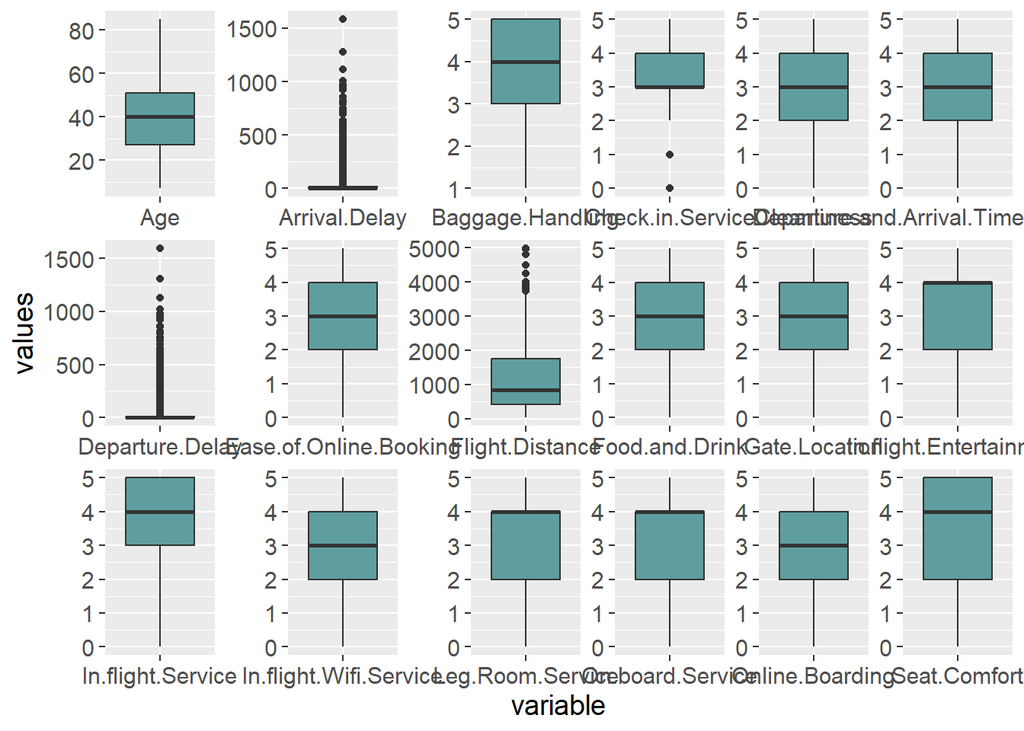

```r
ds_num<-select_if(ds,is.numeric)%>%dplyr::select(-ID)
ds_num_p<-ds_num %>% gather(variable,values,1:18 )
options(repr.plot.width = 14, repr.plot.height = 8)
ggplot(ds_num_p)+
  geom_boxplot(aes(x=variable,y=values),fill="cadetblue") +
  facet_wrap(~variable,ncol=6,scales="free") +
  theme(strip.text.x = element_blank(),
        text = element_text(size=14))
```

**Observation**

- The variables with outliers are departure, arrival, flight distance, and rating on check-in service. None of these variables can be modified as they contain subjective data.

**Outcome Variable**

- This is the dependent variable in the dataset.

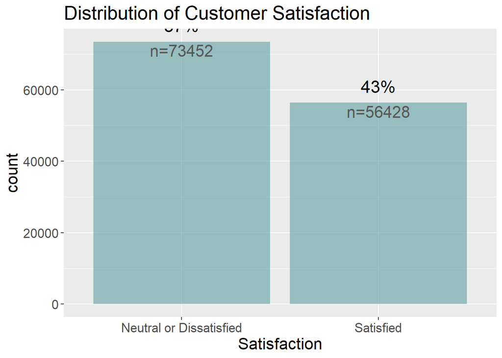

```r
options(repr.plot.width = 14, repr.plot.height = 8)
ggplot(ds, aes(x=`Satisfaction`))+
  geom_bar(fill="cadetblue", alpha=0.6)+
  geom_text(aes(label=scales::percent((..count..)/sum(..count..))), stat="count", vjust = -0.8, size=6)+
  stat_count(aes(y=..count..,label=paste0("n=",..count..)),geom="text",vjust=1.2,size=5.8,color="gray35")+
  labs(x="Satisfaction", title = "Distribution of Customer Satisfaction")+
  theme(text = element_text(size=16))
```

### Correlation Matrix

Let’s take a look at the correlation matrix of the dataset. This will be done in 2 parts:

1. Numerical variables
2. Categorical variables

**Numerical variable Correlation Plot**

```r
ds_cor1 <- cor(subset(ds,select = c(Age, Flight.Distance,Departure.Delay,Arrival.Delay)))
summary(ds_cor1)
```

```
##       Age            Flight.Distance     Departure.Delay
##  Min.   :-0.011206   Min.   :-0.001973   Min.   :-0.0090406
##  1st Qu.:-0.009582   1st Qu.: 0.001308   1st Qu.:-0.0004586
##  Median : 0.045209   Median : 0.050931   Median : 0.4808922
##  Mean   : 0.269803   Mean   : 0.274972   Mean   : 0.4881859
##  3rd Qu.: 0.324595   3rd Qu.: 0.324595   3rd Qu.: 0.9695368
##  Max.   : 1.000000   Max.   : 1.000000   Max.   : 1.0000000
##  Arrival.Delay
##  Min.   :-0.011206
##  1st Qu.:-0.004281
##  Median : 0.478705
##  Mean   : 0.486551
##  3rd Qu.: 0.969537
##  Max.   : 1.000000
```

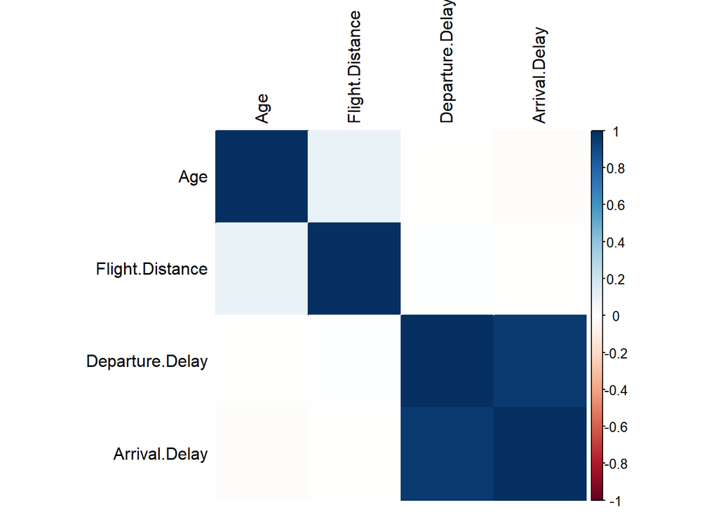

```r
options(repr.plot.width = 14, repr.plot.height = 8)
corrplot(ds_cor1, na.label = " ", method="color", tl.col = "black", tl.cex = 1)
```

**Categorical variable Correlation Plot**

```r
ds_cor2 <- cor(select_if(subset(ds, select=-c(ID, Age, Flight.Distance,Departure.Delay,Arrival.Delay)), is.numeric))
summary(ds_cor2)
```

```
##  Departure.and.Arrival.Time.Convenience Ease.of.Online.Booking
##  Min.   :-0.00838                       Min.   :0.008819
##  1st Qu.: 0.01005                       1st Qu.:0.031729
##  Median : 0.07151                       Median :0.042856
##  Mean   : 0.18752                       Mean   :0.240711
##  3rd Qu.: 0.28147                       3rd Qu.:0.429431
##  Max.   : 1.00000                       Max.   :1.000000
##  Check.in.Service   Online.Boarding    Gate.Location       On.board.Service
##  Min.   :-0.03935   Min.   :0.002756   Min.   :-0.039353   Min.   :-0.02902
##  1st Qu.: 0.08668   1st Qu.:0.093463   1st Qu.:-0.004604   1st Qu.: 0.08045
##  Median : 0.16468   Median :0.218869   Median : 0.001856   Median : 0.14239
##  Mean   : 0.19639   Mean   :0.274479   Mean   : 0.155239   Mean   : 0.26817
##  3rd Qu.: 0.22694   3rd Qu.:0.385994   3rd Qu.: 0.254627   3rd Qu.: 0.40336
##  Max.   : 1.00000   Max.   :1.000000   Max.   : 1.000000   Max.   : 1.00000
##   Seat.Comfort      Leg.Room.Service     Cleanliness        Food.and.Drink
##  Min.   :0.002788   Min.   :-0.005181   Min.   :-0.005918   Min.   :-0.002872
##  1st Qu.:0.070287   1st Qu.: 0.098589   1st Qu.: 0.091941   1st Qu.: 0.033682
##  Median :0.126029   Median : 0.137959   Median : 0.126692   Median : 0.071301
##  Mean   :0.286881   Mean   : 0.227457   Mean   : 0.292342   Mean   : 0.249836
##  3rd Qu.:0.536698   3rd Qu.: 0.343390   3rd Qu.: 0.575885   3rd Qu.: 0.490260
##  Max.   :1.000000   Max.   : 1.000000   Max.   : 1.000000   Max.   : 1.000000
##  In.flight.Service   In.flight.Wifi.Service In.flight.Entertainment
##  Min.   :0.0003104   Min.   :0.04376        Min.   :-0.00838
##  1st Qu.:0.0696803   1st Qu.:0.12066        1st Qu.: 0.14162
##  Median :0.1001923   Median :0.14627        Median : 0.33976
##  Mean   :0.2628888   Mean   :0.28593        Mean   : 0.36316
##  3rd Qu.:0.3969626   3rd Qu.:0.34333        3rd Qu.: 0.56352
##  Max.   :1.0000000   Max.   :1.00000        Max.   : 1.00000
##  Baggage.Handling
##  Min.   :0.0009719
##  1st Qu.:0.0717797
##  Median :0.1087237
##  Mean   :0.2611783
##  3rd Qu.:0.3772057
##  Max.   :1.0000000
```

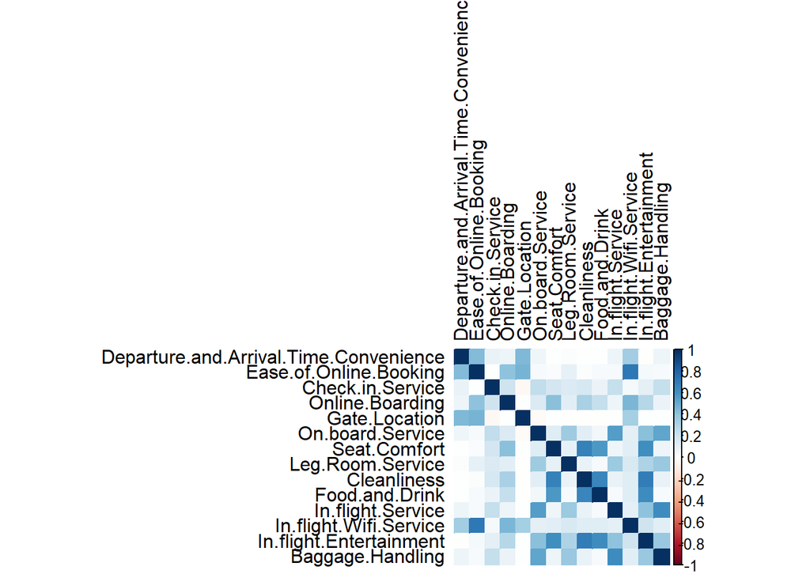

```r
options(repr.plot.width = 14, repr.plot.height = 8)
corrplot(ds_cor2, na.label=" ", tl.cex=1, tl.col="black", method="color")
```

**Observations**

### Exploratory Factor Analysis

#### Step 1: Check factorability

Let’s check whether the dataset is factorable using :

- The Kaiser-Meyer-Olkin test
- Barlett test

**Kaiser-Meyer-Olkin test**

```r
KMO(ds_cor2)
```

```
## Kaiser-Meyer-Olkin factor adequacy
## Call: KMO(r = ds_cor2)
## Overall MSA =  0.78
## MSA for each item =
## Departure.and.Arrival.Time.Convenience                 Ease.of.Online.Booking
##                                   0.75                                   0.68
##                       Check.in.Service                        Online.Boarding
##                                   0.70                                   0.74
##                          Gate.Location                       On.board.Service
##                                   0.71                                   0.83
##                           Seat.Comfort                       Leg.Room.Service
##                                   0.83                                   0.89
##                            Cleanliness                         Food.and.Drink
##                                   0.82                                   0.84
##                      In.flight.Service                 In.flight.Wifi.Service
##                                   0.78                                   0.74
##                In.flight.Entertainment                       Baggage.Handling
##                                   0.77                                   0.82
```

**Observation**

- The KMO test indicates that the dataset is fit for factor analysis as the overall MSA is 0.78 (Overall MSA should be 0-1.0 & >.60).
- The individual MSA of each variable is > 0.60, which suggests none of them have to be removed for EFA

**Barlett Test**

```r
cortest.bartlett(ds_cor2)
```

```
## $chisq
## [1] 542.6405
##
## $p.value
## [1] 1.925279e-65
##
## $df
## [1] 91
```

**Observation**

- Barlett test have a p-value < 0.05, indicating a go-ahead for EFA

#### Step 2: Identify the number of factors

I will use the following methods to determine the number of factors:

- Eigen value method
- Scree plot

**Eigen value method**

Eigen values is a measure that ethat says how much varianceof the variables can a factor explain.

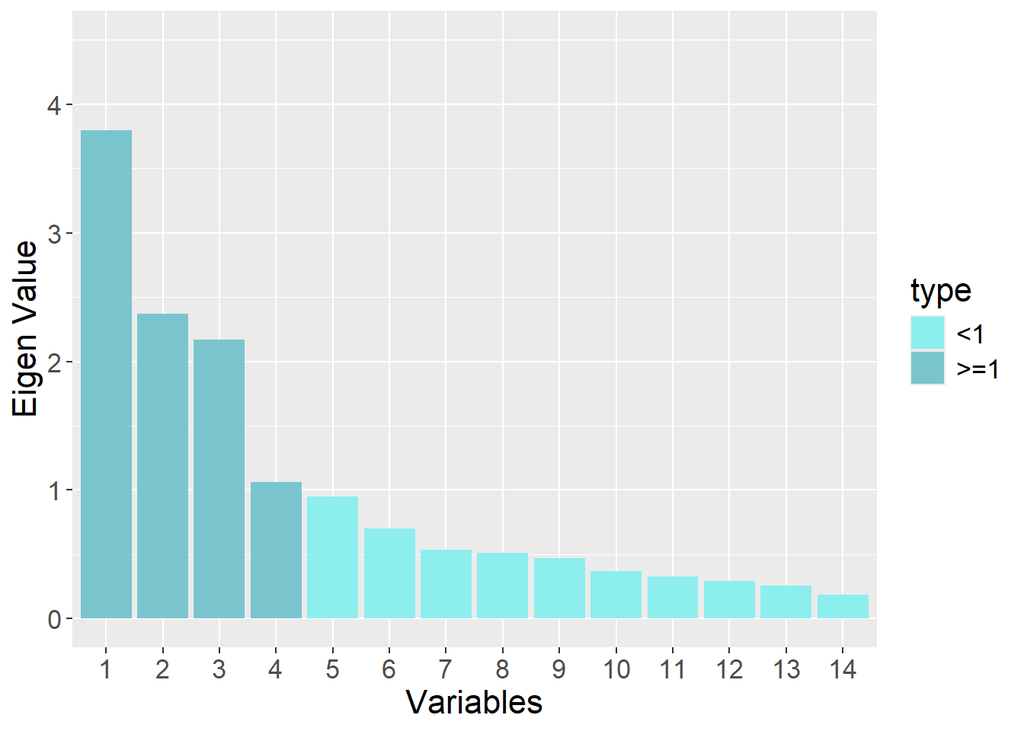

```r
ds.eigen <- data.frame(eigen(ds_cor2)$values)
colnames(ds.eigen)<-"eigen_value"
ds.eigen$type <- ifelse(ds.eigen$`eigen_value`>=1,">=1","<1")

options(repr.plot.width = 14, repr.plot.height = 8)
ggplot(ds.eigen, aes(x= reorder(rownames(ds.eigen),-`eigen_value`) ,y=`eigen_value`, fill=`type`))+
  geom_col()+
  labs(x="Variables", y="Eigen Value")+
  scale_fill_manual(values=c("darkslategray2", "cadetblue3"))+
  ylim(0,4.5)+
theme(text=element_text(size=16))
```

```r
cat("\n Eigen values of variables with ev>=1: " , "\n \n",
    ds.eigen$eigen_value[c(1,2,3,4)] , "\n \n",
    "Sum of eigen values where ev >1 : \n" , sum(ds.eigen$eigen_value[c(1,2,3,4)]), "\n ")
```

```
##
##  Eigen values of variables with ev>=1:
##
##  3.79718 2.371361 2.168999 1.062899
##
##  Sum of eigen values where ev >1 :
##  9.400439
##
```

**Observation**

**Scree plot**

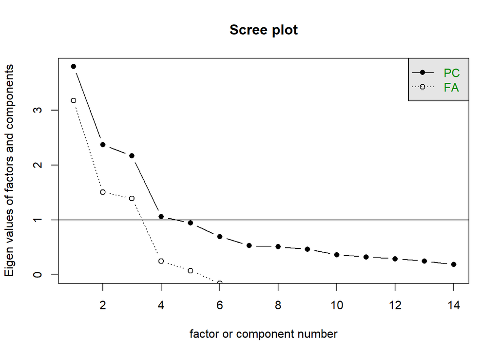

```r
options(repr.plot.width = 14, repr.plot.height = 8)
scree(ds_cor2)
```

**Observation**

- Scree plot suggests 3 factors.

#### Step 3: Determining rotation (orthogonal or oblique)

- Orthogonal rotation (eg. varimax) should be used when the correlation between the factors is at least <0.3 (a general rule of thumb). Statistically, it is easier to interpret the results of orthogonally rotated factors because the factors are assumed to be uncorrelated.
- Oblique rotation (eg. promax) should be used when the correlation between the factors is >0.3. Oblique rotation is less restrictive, i.e., they don’t force factors to correlate but they allow it. In cases where factors are not distinct and load common variables, although it becomes complex to explain, may give a better explanation.

```r
# No rotation
ds.fa1 <- fa(ds_cor2, 3,rotate= "none")
ds.fa1
```

```
## Factor Analysis using method =  minres
## Call: fa(r = ds_cor2, nfactors = 3, rotate = "none")
## Standardized loadings (pattern matrix) based upon correlation matrix
##                                         MR1   MR2   MR3   h2   u2 com
## Departure.and.Arrival.Time.Convenience 0.16  0.48 -0.01 0.26 0.74 1.2
## Ease.of.Online.Booking                 0.32  0.87 -0.14 0.87 0.13 1.3
## Check.in.Service                       0.28 -0.04  0.15 0.10 0.90 1.6
## Online.Boarding                        0.47  0.20 -0.18 0.30 0.70 1.7
## Gate.Location                          0.11  0.49 -0.08 0.26 0.74 1.2
## On.board.Service                       0.49 -0.04  0.51 0.50 0.50 2.0
## Seat.Comfort                           0.65 -0.24 -0.39 0.63 0.37 1.9
## Leg.Room.Service                       0.36  0.02  0.34 0.25 0.75 2.0
## Cleanliness                            0.70 -0.29 -0.41 0.74 0.26 2.0
## Food.and.Drink                         0.58 -0.25 -0.42 0.57 0.43 2.2
## In.flight.Service                      0.49 -0.04  0.63 0.64 0.36 1.9
## In.flight.Wifi.Service                 0.43  0.65 -0.10 0.62 0.38 1.8
## In.flight.Entertainment                0.84 -0.26 -0.05 0.78 0.22 1.2
## Baggage.Handling                       0.47 -0.03  0.60 0.59 0.41 1.9
##
##                        MR1  MR2  MR3
## SS loadings           3.40 1.97 1.73
## Proportion Var        0.24 0.14 0.12
## Cumulative Var        0.24 0.38 0.51
## Proportion Explained  0.48 0.28 0.24
## Cumulative Proportion 0.48 0.76 1.00
##
## Mean item complexity =  1.7
## Test of the hypothesis that 3 factors are sufficient.
##
## df null model =  91  with the objective function =  5.8
## df of  the model are 52  and the objective function was  0.5
##
## The root mean square of the residuals (RMSR) is  0.04
## The df corrected root mean square of the residuals is  0.06
##
## Fit based upon off diagonal values = 0.98
## Measures of factor score adequacy
##                                                    MR1  MR2  MR3
## Correlation of (regression) scores with factors   0.96 0.95 0.90
## Multiple R square of scores with factors          0.91 0.90 0.81
## Minimum correlation of possible factor scores     0.82 0.79 0.63
```

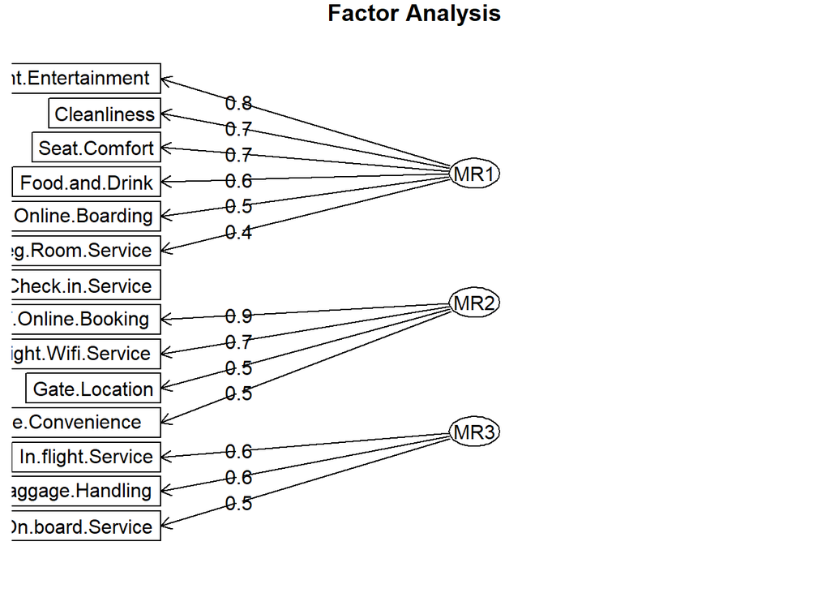

```r
fa.diagram(ds.fa1)
```

**Observation: no rotation**

```r
# Oblique (promax) rotation
options(repr.plot.width = 14, repr.plot.height = 8)
ds.fa2 <- fa(ds_cor2, 3,rotate="promax")
ds.fa2
```

```
## Factor Analysis using method =  minres
## Call: fa(r = ds_cor2, nfactors = 3, rotate = "promax")
## Standardized loadings (pattern matrix) based upon correlation matrix
##                                          MR1   MR3   MR2   h2   u2 com
## Departure.and.Arrival.Time.Convenience -0.08  0.04  0.51 0.26 0.74 1.1
## Ease.of.Online.Booking                 -0.04 -0.04  0.94 0.87 0.13 1.0
## Check.in.Service                        0.10  0.27  0.00 0.10 0.90 1.3
## Online.Boarding                         0.37  0.02  0.33 0.30 0.70 2.0
## Gate.Location                          -0.07 -0.06  0.52 0.26 0.74 1.1
## On.board.Service                       -0.03  0.72 -0.02 0.50 0.50 1.0
## Seat.Comfort                            0.82 -0.07 -0.04 0.63 0.37 1.0
## Leg.Room.Service                       -0.01  0.49  0.05 0.25 0.75 1.0
## Cleanliness                             0.89 -0.07 -0.08 0.74 0.26 1.0
## Food.and.Drink                          0.80 -0.13 -0.06 0.57 0.43 1.1
## In.flight.Service                      -0.12  0.84 -0.03 0.64 0.36 1.0
## In.flight.Wifi.Service                  0.10  0.06  0.75 0.62 0.38 1.0
## In.flight.Entertainment                 0.71  0.35 -0.08 0.78 0.22 1.5
## Baggage.Handling                       -0.11  0.80 -0.02 0.59 0.41 1.0
##
##                        MR1  MR3  MR2
## SS loadings           2.74 2.28 2.08
## Proportion Var        0.20 0.16 0.15
## Cumulative Var        0.20 0.36 0.51
## Proportion Explained  0.39 0.32 0.29
## Cumulative Proportion 0.39 0.71 1.00
##
##  With factor correlations of
##      MR1  MR3  MR2
## MR1 1.00 0.35 0.18
## MR3 0.35 1.00 0.16
## MR2 0.18 0.16 1.00
##
## Mean item complexity =  1.2
## Test of the hypothesis that 3 factors are sufficient.
##
## df null model =  91  with the objective function =  5.8
## df of  the model are 52  and the objective function was  0.5
##
## The root mean square of the residuals (RMSR) is  0.04
## The df corrected root mean square of the residuals is  0.06
##
## Fit based upon off diagonal values = 0.98
## Measures of factor score adequacy
##                                                    MR1  MR3  MR2
## Correlation of (regression) scores with factors   0.95 0.92 0.95
## Multiple R square of scores with factors          0.90 0.85 0.91
## Minimum correlation of possible factor scores     0.80 0.70 0.81
```

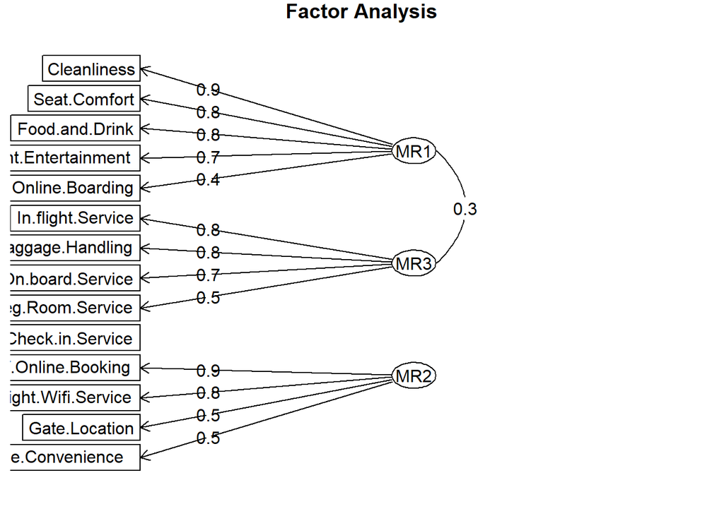

```r
fa.diagram(ds.fa2)
```

**Observation: Oblique (promax) rotation**

```r
# Orthogonal (varimax) rotation
options(repr.plot.width = 14, repr.plot.height = 8)
ds.fa3 <- fa(ds_cor2, 3, rotate = "varimax")
ds.fa3
```

```
## Factor Analysis using method =  minres
## Call: fa(r = ds_cor2, nfactors = 3, rotate = "varimax")
## Standardized loadings (pattern matrix) based upon correlation matrix
##                                          MR1   MR3  MR2   h2   u2 com
## Departure.and.Arrival.Time.Convenience -0.03  0.06 0.50 0.26 0.74 1.0
## Ease.of.Online.Booking                  0.03  0.02 0.93 0.87 0.13 1.0
## Check.in.Service                        0.14  0.29 0.03 0.10 0.90 1.5
## Online.Boarding                         0.39  0.11 0.36 0.30 0.70 2.2
## Gate.Location                          -0.03 -0.03 0.51 0.26 0.74 1.0
## On.board.Service                        0.09  0.70 0.03 0.50 0.50 1.0
## Seat.Comfort                            0.79  0.08 0.03 0.63 0.37 1.0
## Leg.Room.Service                        0.07  0.48 0.08 0.25 0.75 1.1
## Cleanliness                             0.86  0.09 0.00 0.74 0.26 1.0
## Food.and.Drink                          0.75  0.01 0.00 0.57 0.43 1.0
## In.flight.Service                       0.02  0.80 0.02 0.64 0.36 1.0
## In.flight.Wifi.Service                  0.17  0.13 0.76 0.62 0.38 1.2
## In.flight.Entertainment                 0.75  0.47 0.01 0.78 0.22 1.7
## Baggage.Handling                        0.02  0.77 0.03 0.59 0.41 1.0
##
##                        MR1  MR3  MR2
## SS loadings           2.71 2.30 2.09
## Proportion Var        0.19 0.16 0.15
## Cumulative Var        0.19 0.36 0.51
## Proportion Explained  0.38 0.32 0.29
## Cumulative Proportion 0.38 0.71 1.00
##
## Mean item complexity =  1.2
## Test of the hypothesis that 3 factors are sufficient.
##
## df null model =  91  with the objective function =  5.8
## df of  the model are 52  and the objective function was  0.5
##
## The root mean square of the residuals (RMSR) is  0.04
## The df corrected root mean square of the residuals is  0.06
##
## Fit based upon off diagonal values = 0.98
## Measures of factor score adequacy
##                                                    MR1  MR3  MR2
## Correlation of (regression) scores with factors   0.94 0.91 0.95
## Multiple R square of scores with factors          0.89 0.83 0.90
## Minimum correlation of possible factor scores     0.77 0.67 0.81
```

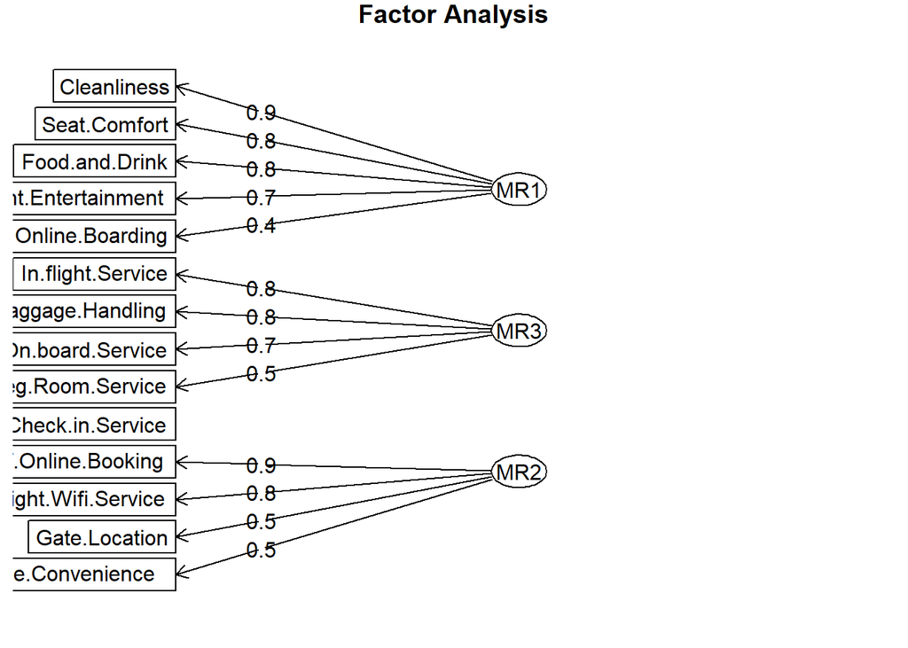

```r
fa.diagram(ds.fa3)
```

**Observation: Orthogonal (varimax) rotation**

- Each factor loads at least 4 variables- this is a positive indication for retaining the factors
- Only check-in service did not load onto any factor
- The loading for each variable onto the factor that it loads is atleast 0.3 (cutoff).

Now let’s take a closer look at the loadings.

```r
print(ds.fa3$loadings, cutoff = 0.3)
```

```
##
## Loadings:
##                                        MR1    MR3    MR2
## Departure.and.Arrival.Time.Convenience                0.504
## Ease.of.Online.Booking                                0.930
## Check.in.Service
## Online.Boarding                         0.394         0.361
## Gate.Location                                         0.507
## On.board.Service                               0.702
## Seat.Comfort                            0.791
## Leg.Room.Service                               0.483
## Cleanliness                             0.858
## Food.and.Drink                          0.753
## In.flight.Service                              0.800
## In.flight.Wifi.Service                                0.759
## In.flight.Entertainment                 0.747  0.467
## Baggage.Handling                               0.766
##
##                  MR1   MR3   MR2
## SS loadings    2.708 2.300 2.092
## Proportion Var 0.193 0.164 0.149
## Cumulative Var 0.193 0.358 0.507
```

**Observation**

- Factor 1: food and drink,seat comfort, inflight entertainment, cleanliness
- Factor 2: inflight wifi, departure arrival time convenience, online booking ease, gate location
- Factor 3: on board service, leg room service, baggage handling, inflight services
- online boarding is a low-contribution variable so I chose to leave it out of the factors

Let’s check how reliable the factors are using Cronbach’s alpha.

#### Reliability of factors using Cronbach’s alpha

- to do this, first the factors have to be grouped together

```r
if (!require(ltm)) {
  install.packages("ltm")
}
library(ltm)
factor1 <- ds_cor2[, c("Food.and.Drink", "Seat.Comfort", "In.flight.Entertainment", "Cleanliness")]
factor2 <- ds_cor2[,c("In.flight.Wifi.Service","Departure.and.Arrival.Time.Convenience", "Ease.of.Online.Booking","Gate.Location")]
factor3 <- ds_cor2[,c("In.flight.Entertainment", "On.board.Service","Leg.Room.Service","Baggage.Handling","In.flight.Service" )]
cronbach.alpha(factor1)
```

```
##
## Cronbach's alpha for the 'factor1' data-set
##
## Items: 4
## Sample units: 14
## alpha: 0.954
```

```r
cronbach.alpha(factor2)
```

```
##
## Cronbach's alpha for the 'factor2' data-set
##
## Items: 4
## Sample units: 14
## alpha: 0.881
```

```r
cronbach.alpha(factor3)
```

```
##
## Cronbach's alpha for the 'factor3' data-set
##
## Items: 5
## Sample units: 14
## alpha: 0.829
```

**Observation**

- the Cronbach’s alpha for each factor is more than 0.80. This indicates a good level of factor reliability.

*Caution: Cronbach’s alpha > 0.95 could hint to redundancy*

### Exploratory Factor Analysis Interpretation

Based on the variables in the the factors, I interpret the latent variables as:

### Logistic Regression

The dependent variable in the dataset is binary (“neutral or dissatisfied” and “satisfied”). Therefore, it is fitting to use logistic regression.

```r
# install.packages(c("caret","broom","MASS","ROCR"))
library(MASS)
library(ROCR)
library(broom)
library(caret)
```

Before building the logistic regression model, we have to make sure the dataset is ready. To do that:

- First, check if there is a satisfaction imbalance in the DV
- Next, the DV which should be categotical

```r
table(ds$satisfaction)
```

```
## < table of extent 0 >
```

```r
str(ds)
```

```
## 'data.frame':    129880 obs. of  24 variables:
##  $ ID                                    : int  1 2 3 4 5 6 7 8 9 10 ...
##  $ Gender                                : chr  "Male" "Female" "Male" "Male" ...
##  $ Age                                   : int  48 35 41 50 49 43 43 60 50 38 ...
##  $ Customer.Type                         : chr  "First-time" "Returning" "Returning" "Returning" ...
##  $ Type.of.Travel                        : chr  "Business" "Business" "Business" "Business" ...
##  $ Class                                 : chr  "Business" "Business" "Business" "Business" ...
##  $ Flight.Distance                       : int  821 821 853 1905 3470 3788 1963 853 2607 2822 ...
##  $ Departure.Delay                       : num  2 26 0 0 0 0 0 0 0 13 ...
##  $ Arrival.Delay                         : num  5 39 0 0 1 0 0 3 0 0 ...
##  $ Departure.and.Arrival.Time.Convenience: int  3 2 4 2 3 4 3 3 1 2 ...
##  $ Ease.of.Online.Booking                : int  3 2 4 2 3 4 3 4 1 5 ...
##  $ Check.in.Service                      : int  4 3 4 3 3 3 4 3 3 3 ...
##  $ Online.Boarding                       : int  3 5 5 4 5 5 4 4 2 5 ...
##  $ Gate.Location                         : int  3 2 4 2 3 4 3 4 1 2 ...
##  $ On.board.Service                      : int  3 5 3 5 3 4 5 3 4 5 ...
##  $ Seat.Comfort                          : int  5 4 5 5 4 4 5 4 3 4 ...
##  $ Leg.Room.Service                      : int  2 5 3 5 4 4 5 4 4 5 ...
##  $ Cleanliness                           : int  5 5 5 4 5 3 4 4 3 4 ...
##  $ Food.and.Drink                        : int  5 3 5 4 4 3 5 4 3 2 ...
##  $ In.flight.Service                     : int  5 5 3 5 3 4 5 3 4 5 ...
##  $ In.flight.Wifi.Service                : int  3 2 4 2 3 4 3 4 4 2 ...
##  $ In.flight.Entertainment               : int  5 5 3 5 3 4 5 3 4 5 ...
##  $ Baggage.Handling                      : int  5 5 3 5 3 4 5 3 4 5 ...
##  $ Satisfaction                          : chr  "Neutral or Dissatisfied" "Satisfied" "Satisfied" "Satisfied" ...
```

```r
ds <- read.csv("airline_passenger_satisfaction.csv")

ds$Departure.Delay = as.numeric(ds$Departure.Delay)
ds$Arrival.Delay[is.na(ds$Arrival.Delay)] <-0
any(is.na(ds))
```

```
## [1] FALSE
```

```r
## 75% of the sample size
smp_size <- floor(0.8 * nrow(ds))

## set the seed to make your partition reproducible
set.seed(321)
train_ind <- sample(seq_len(nrow(ds)), size = smp_size)

ds_train <- ds[train_ind, ]
ds_test <- ds[-train_ind, ]

ds_train <- subset(ds_train, select=-c(ID))
ds_train$Departure.Delay = as.numeric(ds_train$Departure.Delay)
ds_train$Arrival.Delay[is.na(ds_train$Arrival.Delay)] <-0

ds_train$Satisfaction <- ifelse(ds_train$Satisfaction=="Satisfied",1,0)
ds_train$Satisfaction <- factor(ds_train$Satisfaction, levels = c(0, 1))

ds_train$Gender <- as.factor(ds_train$Gender)
ds_train$Customer.Type <- as.factor(ds_train$Customer.Type)
ds_train$Type.of.Travel <- as.factor(ds_train$Type.of.Travel)
ds_train$Class <- as.factor(ds_train$Class)
ds_train$In.flight.Wifi.Service <- as.factor(ds_train$In.flight.Wifi.Service)
ds_train$Departure.and.Arrival.Time.Convenience <- as.factor(ds_train$Departure.and.Arrival.Time.Convenience)
ds_train$Ease.of.Online.Booking <- as.factor(ds_train$Ease.of.Online.Booking)
ds_train$Gate.Location <- as.factor(ds_train$Gate.Location)
ds_train$Food.and.Drink <- as.factor(ds_train$Food.and.Drink)
ds_train$Online.Boarding <- as.factor(ds_train$Online.Boarding)
ds_train$Seat.Comfort <- as.factor(ds_train$Seat.Comfort)
ds_train$Leg.Room.Service <- as.factor(ds_train$Leg.Room.Service)
ds_train$In.flight.Entertainment <- as.factor(ds_train$In.flight.Entertainment)
ds_train$On.board.Service <- as.factor(ds_train$On.board.Service)
ds_train$Check.in.Service <- as.factor(ds_train$Check.in.Service)
ds_train$In.flight.Service <- as.factor(ds_train$In.flight.Service)
ds_train$Cleanliness <- as.factor(ds_train$Cleanliness)
ds_train$Baggage.Handling <- as.factor(ds_train$Baggage.Handling)

ds_train <- subset(ds_train, On.board.Service != "0")
ds_train$On.board.Service <- droplevels(ds_train$On.board.Service)
ds_train <- subset(ds_train, Check.in.Service != "0")
ds_train$Check.in.Service <- droplevels(ds_train$Check.in.Service)
ds_train <- subset(ds_train, Seat.Comfort != "0")
ds_train$Seat.Comfort <- droplevels(ds_train$Seat.Comfort)

ds_train <- subset(ds_train, In.flight.Service != "0")
ds_train$In.flight.Service <- droplevels(ds_train$In.flight.Service)

ds_train <- subset(ds_train, Gate.Location != "0")
ds_train$Gate.Location <- droplevels(ds_train$Gate.Location)

ds_train <- subset(ds_train, Cleanliness != "0")
ds_train$Cleanliness <- droplevels(ds_train$Cleanliness)

ds_train <- subset(ds_train, In.flight.Entertainment != "0")
ds_train$In.flight.Entertainment <- droplevels(ds_train$In.flight.Entertainment)

str(ds_train)
```

```
## 'data.frame':    103887 obs. of  23 variables:
##  $ Gender                                : Factor w/ 2 levels "Female","Male": 2 1 1 2 2 1 1 2 2 2 ...
##  $ Age                                   : int  37 30 41 8 57 45 48 42 33 24 ...
##  $ Customer.Type                         : Factor w/ 2 levels "First-time","Returning": 1 2 2 1 2 1 2 2 2 2 ...
##  $ Type.of.Travel                        : Factor w/ 2 levels "Business","Personal": 1 1 1 1 1 1 1 1 1 2 ...
##  $ Class                                 : Factor w/ 3 levels "Business","Economy",..: 1 3 1 2 1 2 1 1 1 2 ...
##  $ Flight.Distance                       : int  304 284 143 1319 3334 438 1831 3228 236 525 ...
##  $ Departure.Delay                       : num  0 0 0 0 0 0 0 0 2 54 ...
##  $ Arrival.Delay                         : num  0 0 0 0 0 0 0 0 0 45 ...
##  $ Departure.and.Arrival.Time.Convenience: Factor w/ 6 levels "0","1","2","3",..: 5 5 4 3 2 5 6 5 4 3 ...
##  $ Ease.of.Online.Booking                : Factor w/ 6 levels "0","1","2","3",..: 5 5 4 3 2 3 3 5 4 3 ...
##  $ Check.in.Service                      : Factor w/ 5 levels "1","2","3","4",..: 5 1 3 3 3 3 3 5 1 2 ...
##  $ Online.Boarding                       : Factor w/ 6 levels "0","1","2","3",..: 5 4 3 3 6 3 5 6 2 3 ...
##  $ Gate.Location                         : Factor w/ 5 levels "1","2","3","4",..: 2 4 3 4 1 4 5 4 3 4 ...
##  $ On.board.Service                      : Factor w/ 5 levels "1","2","3","4",..: 5 1 4 1 4 5 2 4 4 2 ...
##  $ Seat.Comfort                          : Factor w/ 5 levels "1","2","3","4",..: 3 3 4 1 5 1 4 2 1 2 ...
##  $ Leg.Room.Service                      : Factor w/ 6 levels "0","1","2","3",..: 5 6 5 4 5 4 4 5 2 6 ...
##  $ Cleanliness                           : Factor w/ 5 levels "1","2","3","4",..: 3 3 3 1 5 5 4 3 1 2 ...
##  $ Food.and.Drink                        : Factor w/ 6 levels "0","1","2","3",..: 4 4 3 2 3 6 3 4 2 3 ...
##  $ In.flight.Service                     : Factor w/ 5 levels "1","2","3","4",..: 5 4 4 3 4 4 2 4 4 4 ...
##  $ In.flight.Wifi.Service                : Factor w/ 6 levels "0","1","2","3",..: 5 4 4 3 2 3 6 5 2 3 ...
##  $ In.flight.Entertainment               : Factor w/ 5 levels "1","2","3","4",..: 3 3 4 1 4 5 2 4 1 2 ...
##  $ Baggage.Handling                      : Factor w/ 5 levels "1","2","3","4",..: 5 3 5 3 4 3 2 4 4 3 ...
##  $ Satisfaction                          : Factor w/ 2 levels "0","1": 2 1 2 1 2 1 2 2 1 1 ...
```

Let’s build the logistic regression model with all variables (Model 1)

```r
set.seed(123)
model1 <- glm(Satisfaction ~ Gender + Customer.Type + Age +

                 Type.of.Travel + Class + Flight.Distance + In.flight.Wifi.Service +

                 Departure.and.Arrival.Time.Convenience + Ease.of.Online.Booking +
                 Gate.Location + Food.and.Drink + Online.Boarding + Seat.Comfort +
                 In.flight.Entertainment + On.board.Service + Leg.Room.Service +
                 Baggage.Handling + Check.in.Service + In.flight.Service +
                 Cleanliness
               + Departure.Delay + Arrival.Delay ,
               data = ds_train, family = "binomial")
summary(model1)
```

```
##
## Call:
## glm(formula = Satisfaction ~ Gender + Customer.Type + Age + Type.of.Travel +
##     Class + Flight.Distance + In.flight.Wifi.Service + Departure.and.Arrival.Time.Convenience +
##     Ease.of.Online.Booking + Gate.Location + Food.and.Drink +
##     Online.Boarding + Seat.Comfort + In.flight.Entertainment +
##     On.board.Service + Leg.Room.Service + Baggage.Handling +
##     Check.in.Service + In.flight.Service + Cleanliness + Departure.Delay +
##     Arrival.Delay, family = "binomial", data = ds_train)
##
## Coefficients:
##                                           Estimate Std. Error z value Pr(>|z|)
## (Intercept)                              2.204e+01  8.943e+01   0.246 0.805359
## GenderMale                               7.016e-02  2.733e-02   2.567 0.010261
## Customer.TypeReturning                   3.352e+00  4.939e-02  67.883  < 2e-16
## Age                                     -2.667e-03  1.021e-03  -2.612 0.009010
## Type.of.TravelPersonal                  -4.303e+00  5.507e-02 -78.139  < 2e-16
## ClassEconomy                            -5.967e-01  3.725e-02 -16.020  < 2e-16
## ClassEconomy Plus                       -8.286e-01  6.058e-02 -13.678  < 2e-16
## Flight.Distance                          1.260e-05  1.537e-05   0.820 0.412371
## In.flight.Wifi.Service1                 -2.373e+01  8.941e+01  -0.265 0.790691
## In.flight.Wifi.Service2                 -2.397e+01  8.941e+01  -0.268 0.788602
## In.flight.Wifi.Service3                 -2.402e+01  8.941e+01  -0.269 0.788219
## In.flight.Wifi.Service4                 -2.245e+01  8.941e+01  -0.251 0.801779
## In.flight.Wifi.Service5                 -1.688e+01  8.941e+01  -0.189 0.850220
## Departure.and.Arrival.Time.Convenience1  4.016e-01  9.321e-02   4.308 1.64e-05
## Departure.and.Arrival.Time.Convenience2  4.565e-01  8.939e-02   5.107 3.28e-07
## Departure.and.Arrival.Time.Convenience3  3.075e-01  8.591e-02   3.579 0.000345
## Departure.and.Arrival.Time.Convenience4 -6.555e-01  7.730e-02  -8.480  < 2e-16
## Departure.and.Arrival.Time.Convenience5 -8.697e-01  8.502e-02 -10.229  < 2e-16
## Ease.of.Online.Booking1                  2.846e+00  8.682e-01   3.278 0.001047
## Ease.of.Online.Booking2                  2.884e+00  8.682e-01   3.322 0.000894
## Ease.of.Online.Booking3                  3.334e+00  8.679e-01   3.842 0.000122
## Ease.of.Online.Booking4                  4.148e+00  8.677e-01   4.780 1.75e-06
## Ease.of.Online.Booking5                  3.512e+00  8.681e-01   4.046 5.22e-05
## Gate.Location2                           7.020e-02  6.080e-02   1.154 0.248304
## Gate.Location3                          -1.432e-01  5.622e-02  -2.546 0.010887
## Gate.Location4                          -3.927e-01  5.832e-02  -6.734 1.65e-11
## Gate.Location5                          -6.155e-01  7.542e-02  -8.160 3.34e-16
## Food.and.Drink1                         -1.082e+00  1.414e+00  -0.766 0.443896
```

[output cut: 112 more lines]

```
## Cleanliness3                            ***
## Cleanliness4                            ***
## Cleanliness5                            ***
## Departure.Delay                         ***
## Arrival.Delay                           ***
## ---
## Signif. codes:  0 '***' 0.001 '**' 0.01 '*' 0.05 '.' 0.1 ' ' 1
##
## (Dispersion parameter for binomial family taken to be 1)
##
##     Null deviance: 142238  on 103886  degrees of freedom
## Residual deviance:  36933  on 103815  degrees of freedom
## AIC: 37077
##
## Number of Fisher Scoring iterations: 17
```

**Observations**